# Should We Trust Election Polls?

# Investigation of the Turkish Case

## Overall Analysis

The credibility of the polling firms became a hot topic prior to the 2019 local elections in Turkey, as President Erdogan expressed his discontent regarding the forecasting performances of those firms. On top of that, the unforeseen win of the underdog candidate Imamoglu over the favorite candidate Yildirim in the Istanbul election raised further questions about the credibility issue. In this study, we examine seven elections from 2011 to 2019, investigate the forecasting abilities of the polling firms and tackle the question of whether some firms are biased towards certain parties. For this purpose, we take election forecasts from Wikipedia and analyze the performances of the polling firms using R.

In this study, we evaluate the forecast performances of the firms based on both the size of the estimation errors and the trends in which the estimation errors follow. An estimation error can be defined as the margin between a forecast value and the actual result. In that context, it is expected that the estimation errors of a successful and unbiased polling firm get smaller as the elections approach. Although the absolute values of the estimation errors should decrease in time as a necessary condition for being credible, it is certainly not enough. The size of the estimation error should be statistically reasonable as well. To this end, we plot the estimation errors against time for each of the seven elections in the 2011-2019 period, investigate the forecast performances of the polling firms and try to detect any systematic biasedness.

The analyses of a referendum, 4 general and 2 local elections are presented in the subsections in detail. However, to reach a clear conclusion and be reader-friendly, we present only the relevant figures contributing to our case rather than presenting all of the figures here.

It is noticeable that up to the 2015 November election, namely the 2011 general, 2014 local and 2015 June general elections, the estimation errors for the 4 major parties follow a decreasing trend. That is, the vast majority of the polling firms improve their forecasts as the remaining time for the elections decreases. However, it is striking that in the November 2015 election, the forecast performances of the firms deteriorate significantly. It is seen that a lot of forecasts diverge from the actual result as the election approaches. On top of that, the size of the estimation errors seems significantly higher for almost all firms compared to the previous elections. The deterioration in the forecast performances raised questions regarding the credibilities of the polling firms. However, it is worth mentioning that the November election was held under “extraordinary” conditions, which may be the underlying reason behind the “failures” of the firms. For that reason, we take the 2015 November election as an outlier and do not use it in our overall election analysis.

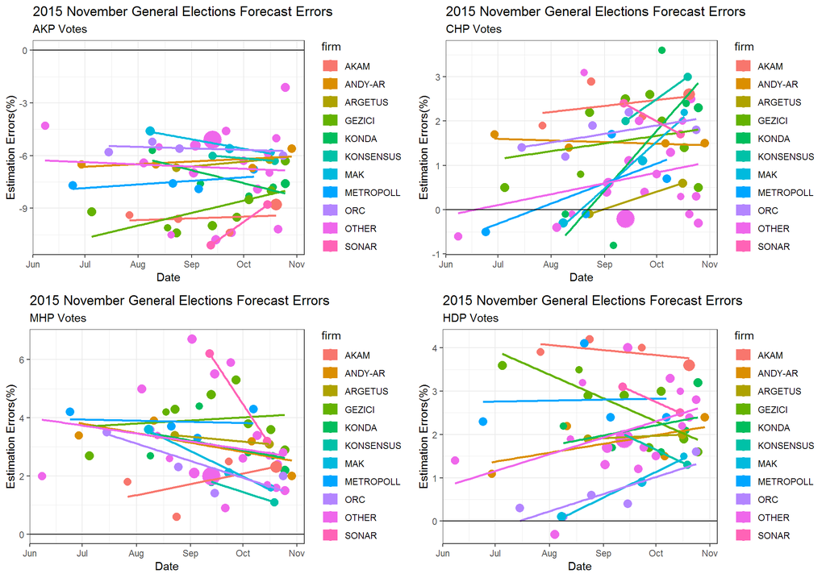

It is also interesting, that even if we exclude the 2015 November election, the deviation from the actual outcomes and the gap between the forecasts of the firms do not follow a diminishing trend. It may be interpreted that the experience and new technology did not bring about an improvement in the forecasting performances.

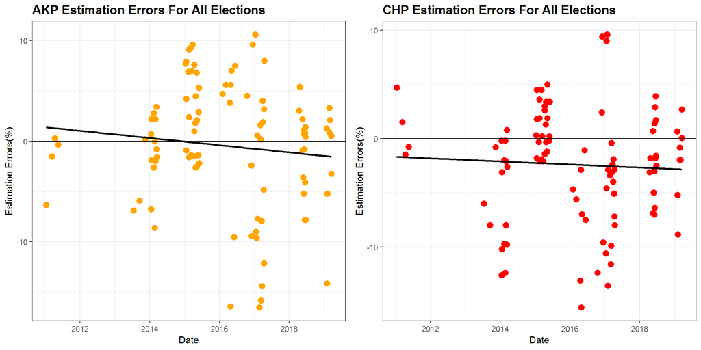

On the other hand, our analysis shows that the reason behind the huge gaps among forecasts might not be purely related to the material errors and constraints, but also might be partially related to the biasedness of some of the polling firms. As previously mentioned, in our analysis we investigate 7 elections and observe that the forecasts of some polling firms do not converge to the actual result in time. It is suggested that the divergence and significantly higher estimation errors compared to the peers may be interpreted as a sign for biasedness if the estimation errors for a specific party’s polling rate by a specific firm persistently stay significantly lower or higher through different elections. For that reason, the number of observations from different elections is crucial for our analysis. However, as the number of polling firms that have forecasts for the majority of the elections is limited, we focus on those which meet that criteria.

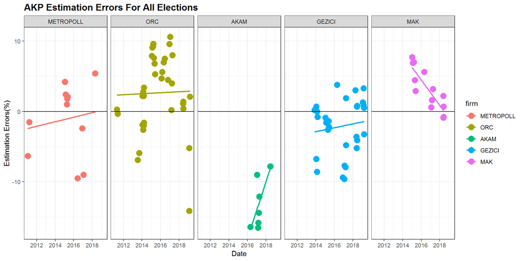

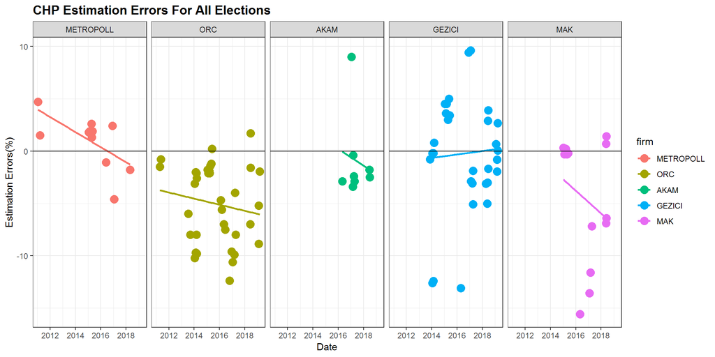

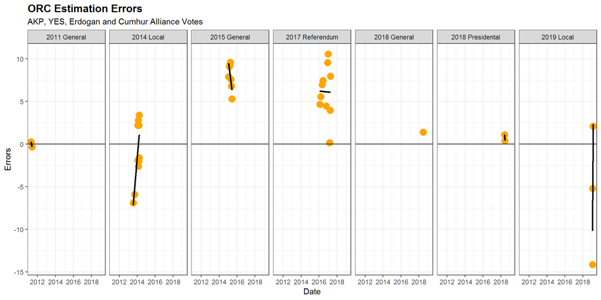

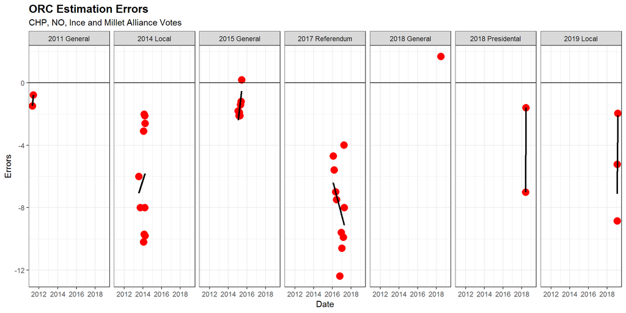

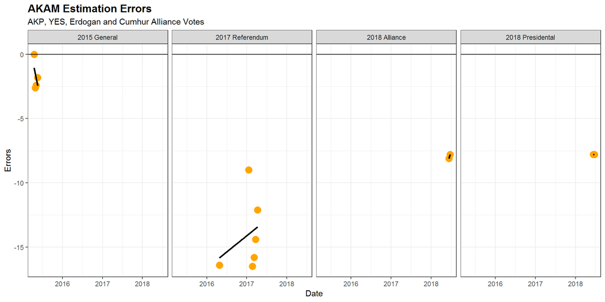

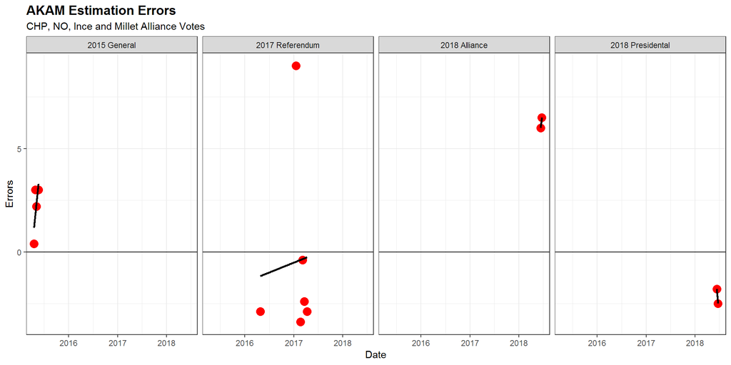

## Detailed Analysis

### 2011

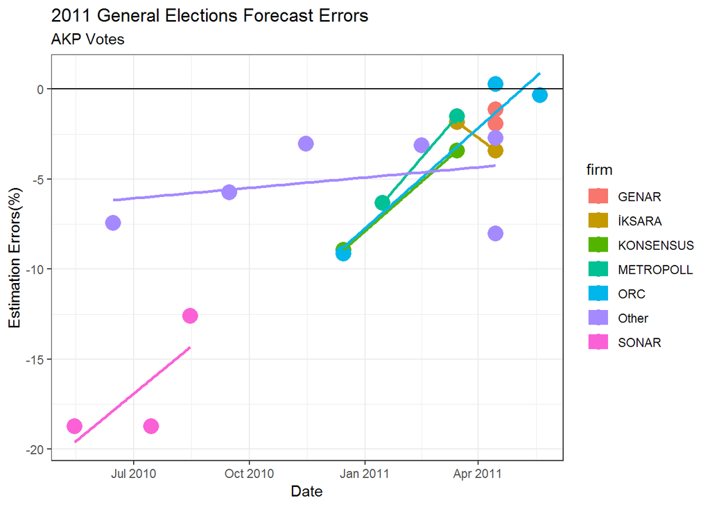

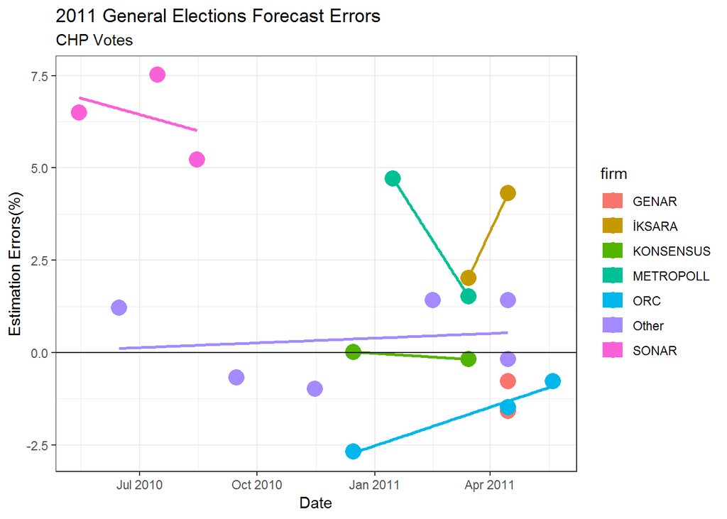

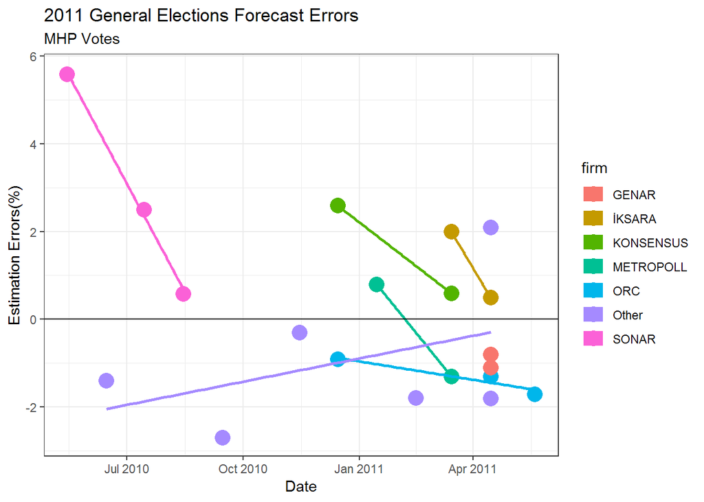

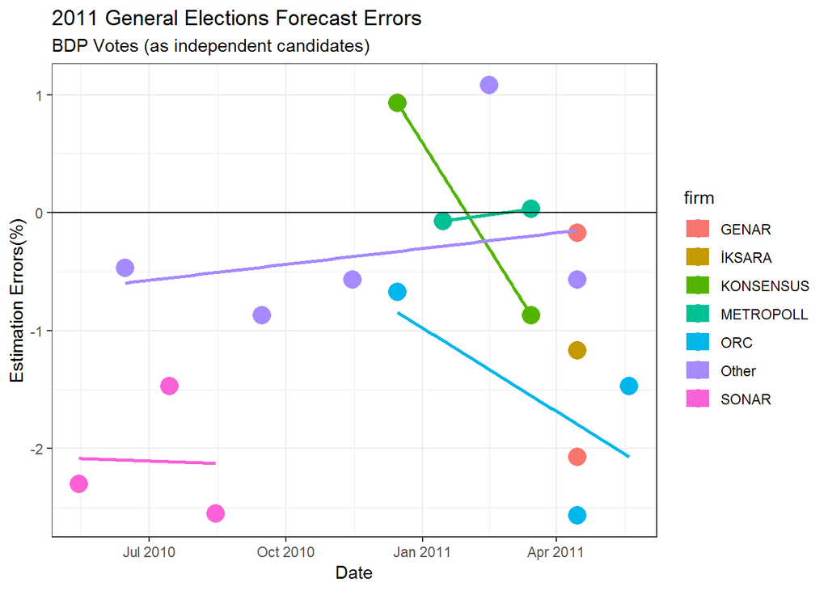

### 2014

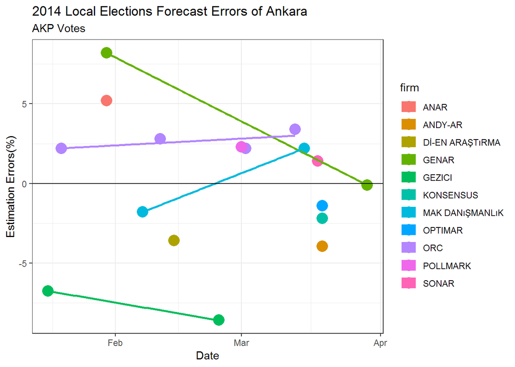

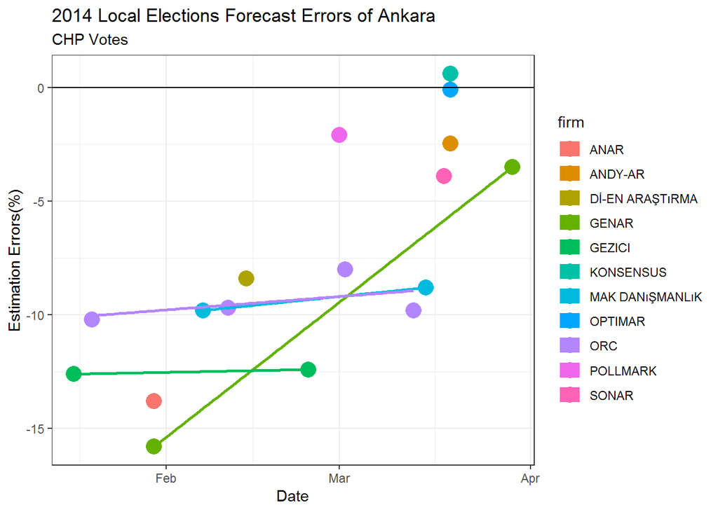

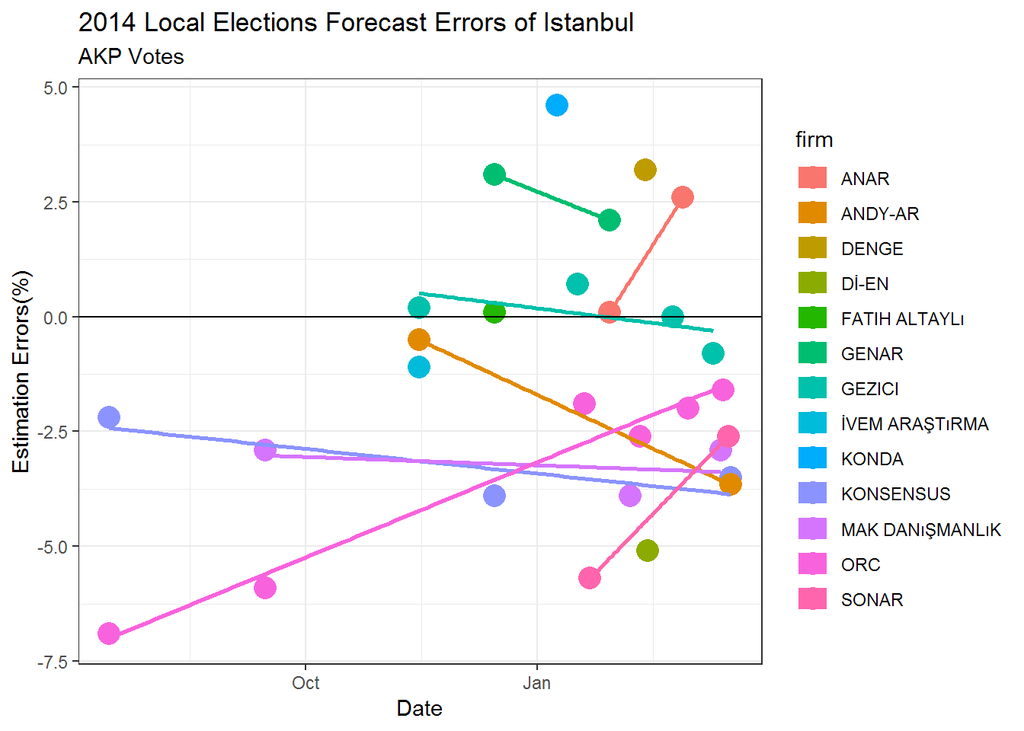

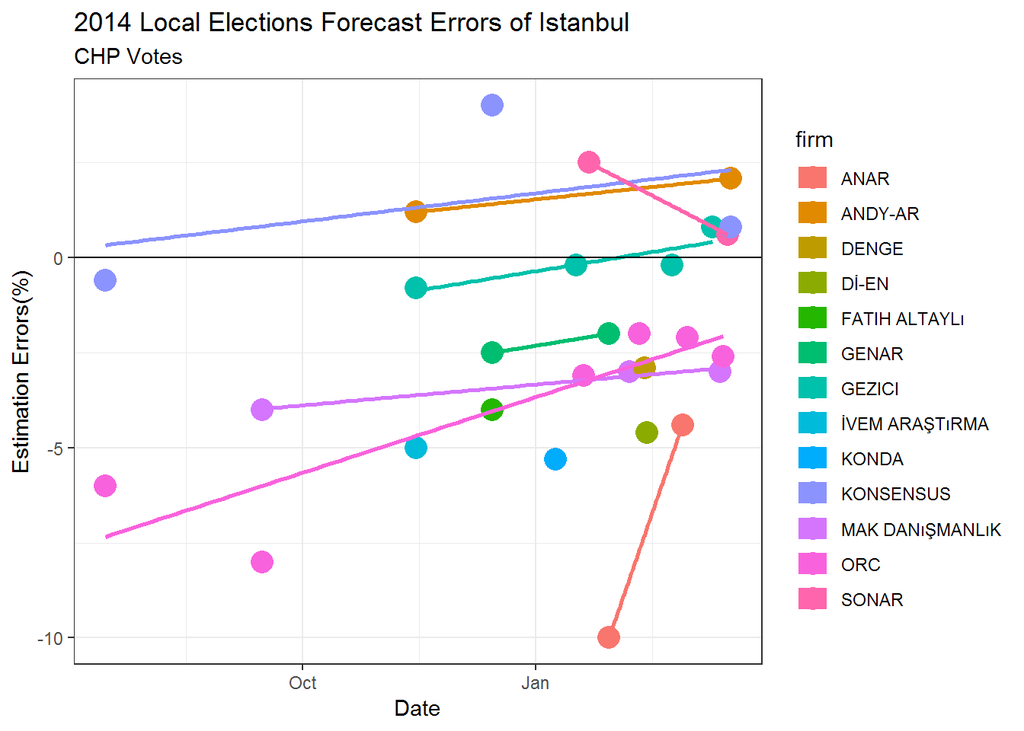

### 2015

#### 2015 June

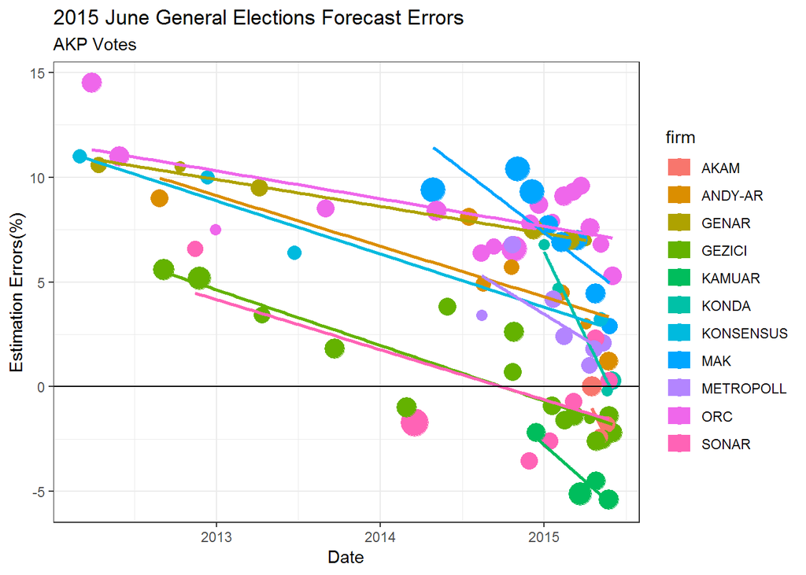

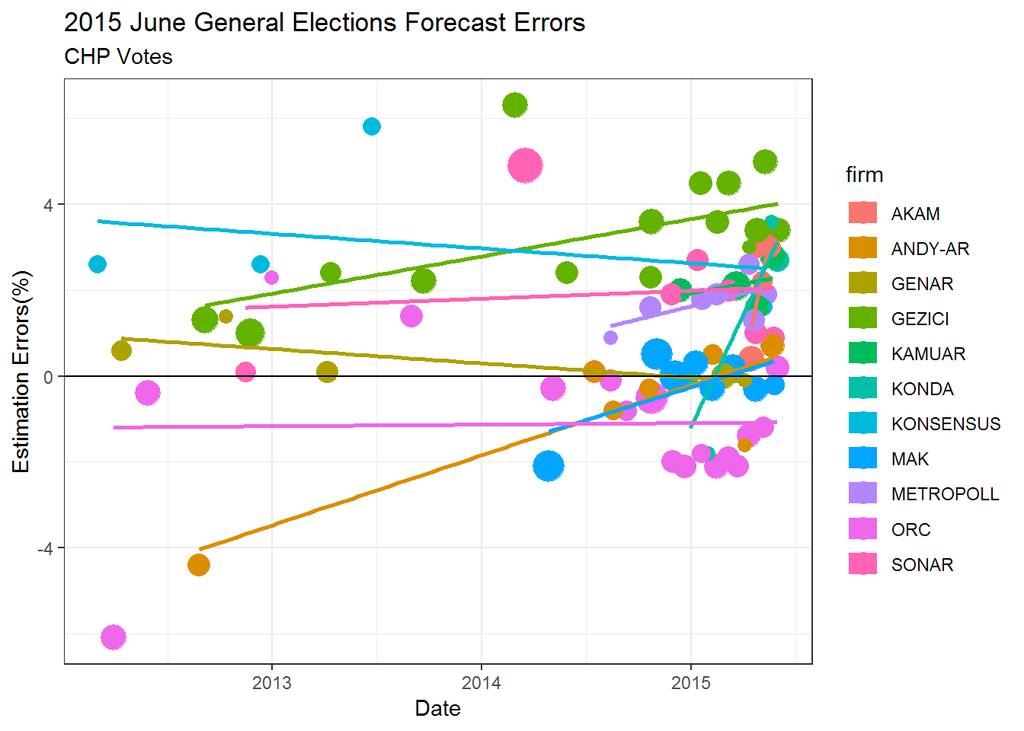

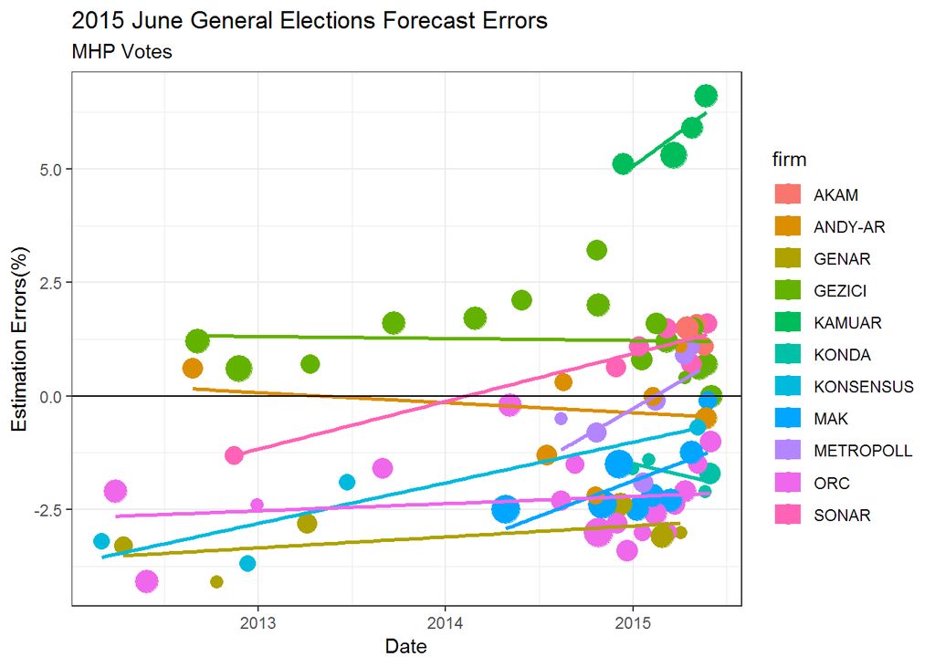

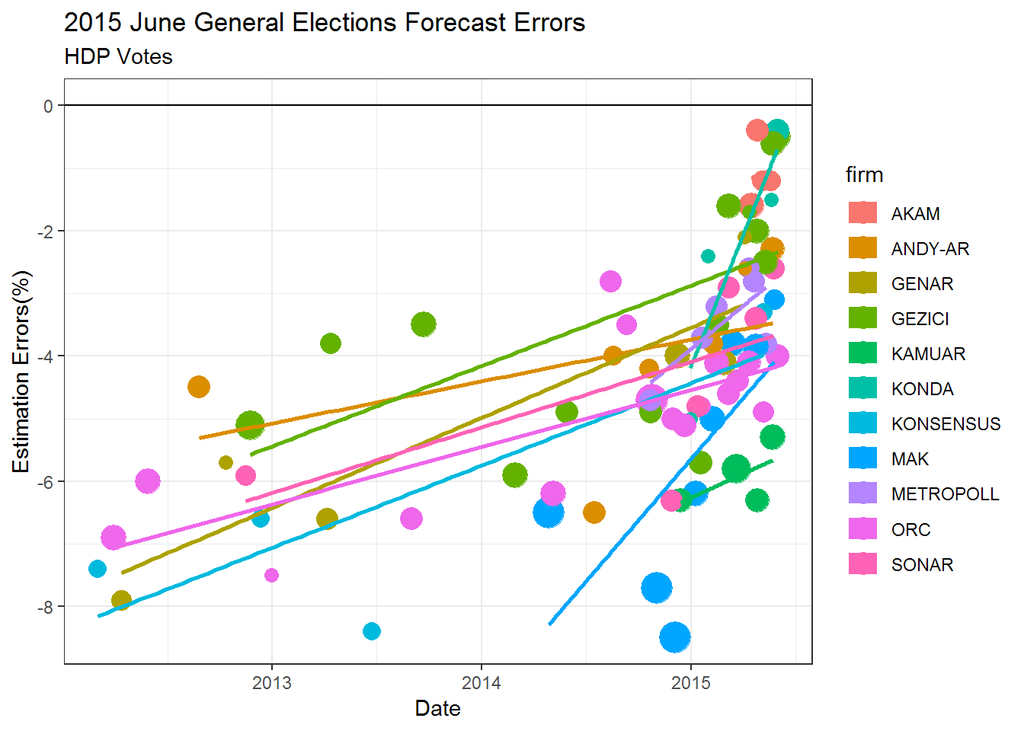

#### 2015 November

[figure not shown]

[figure not shown]

[figure not shown]

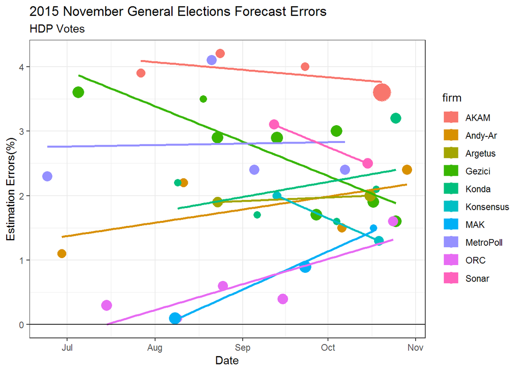

### 2017

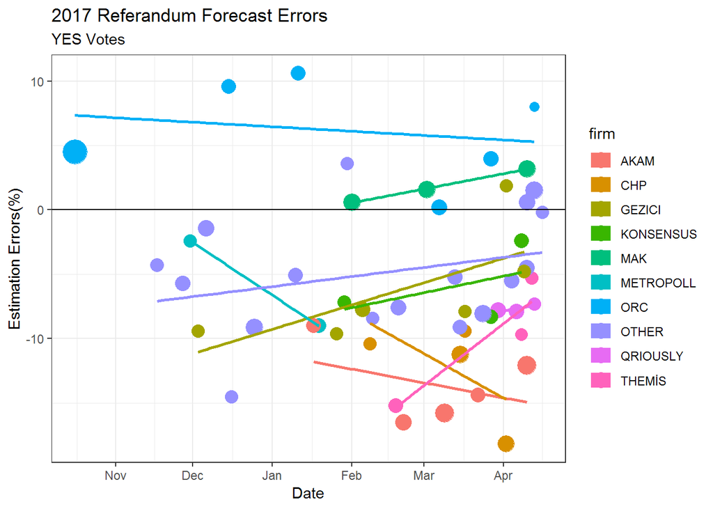

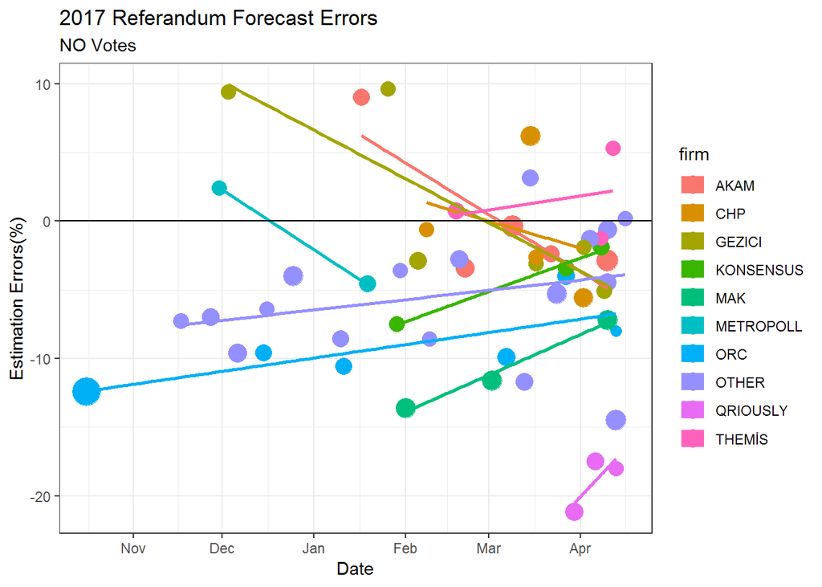

### 2018

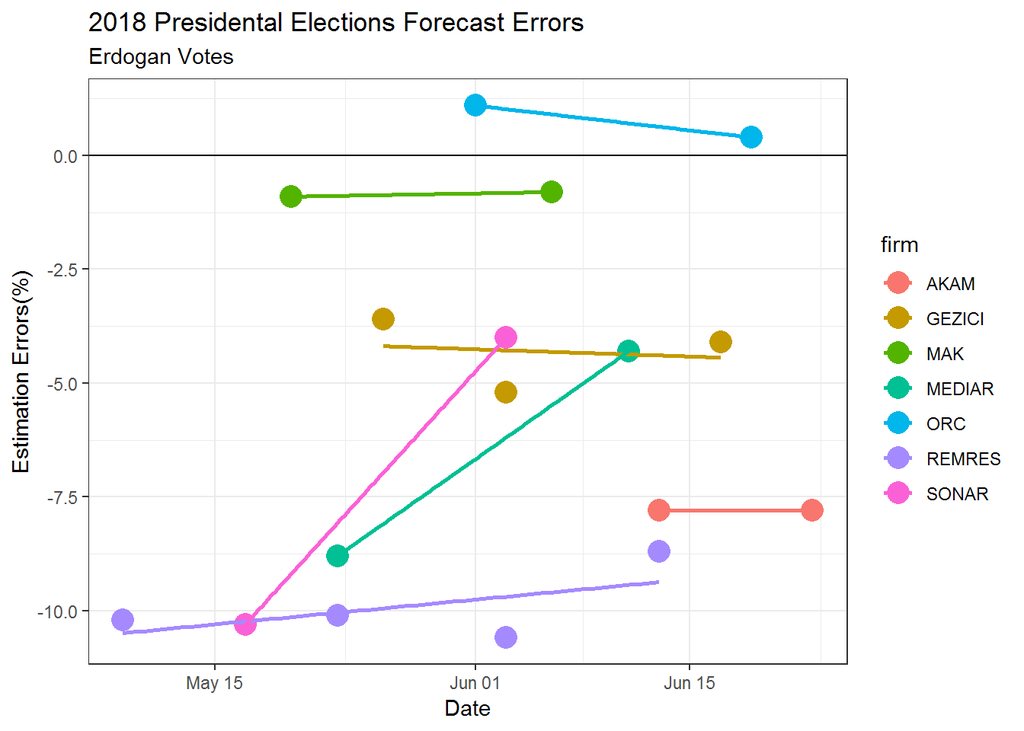

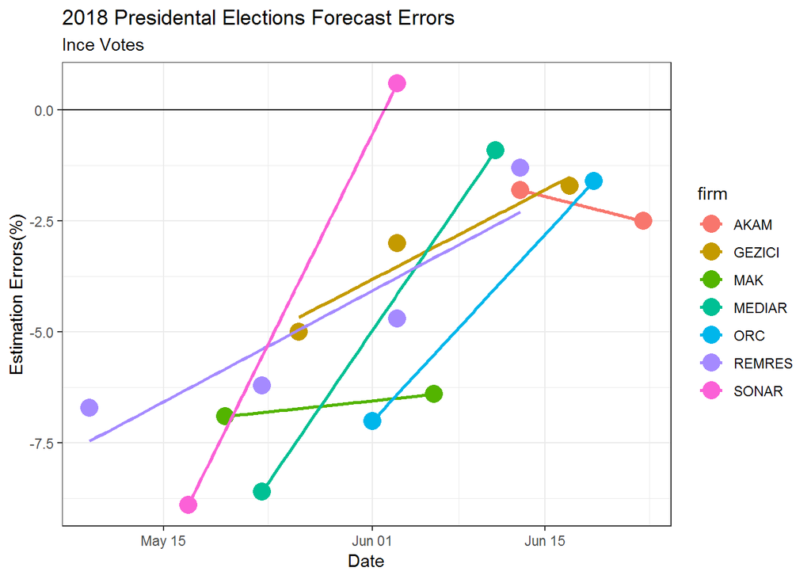

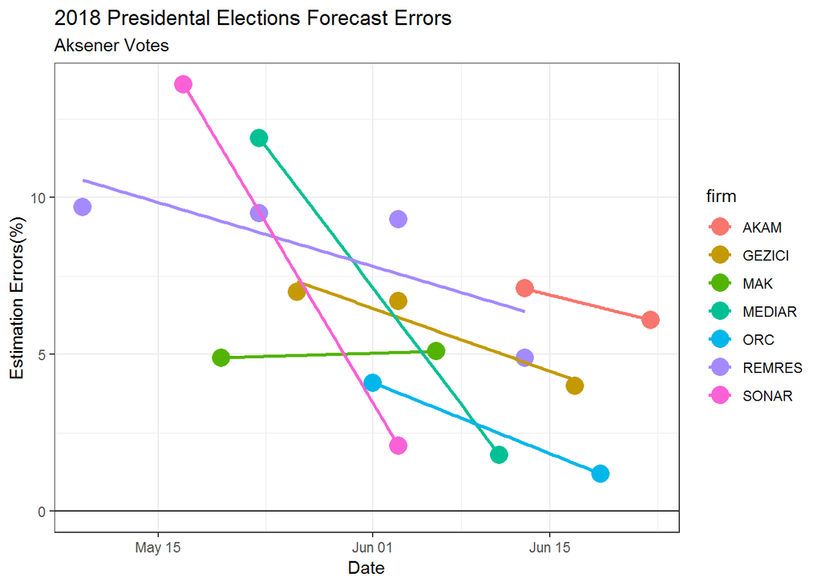

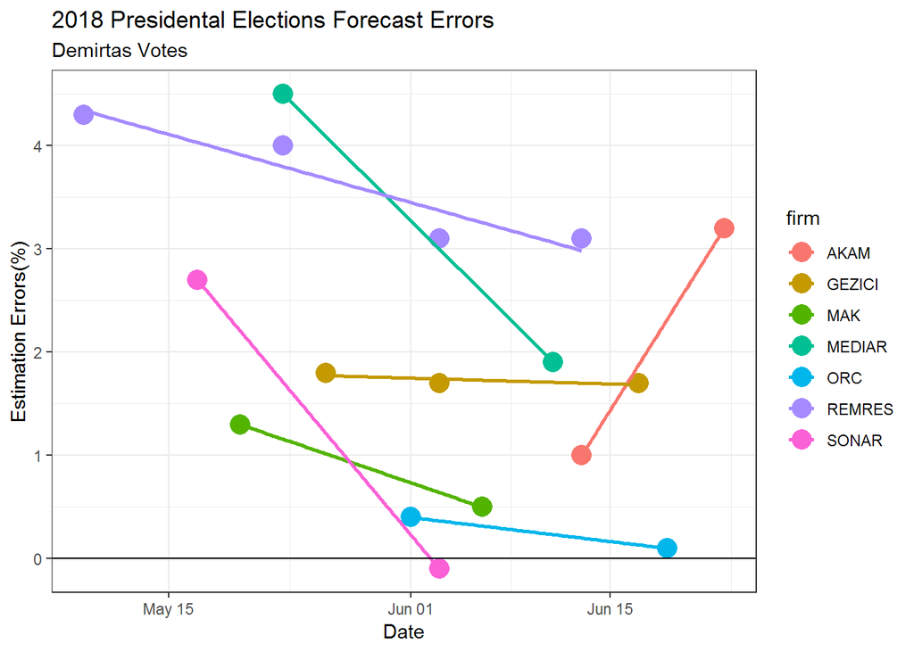

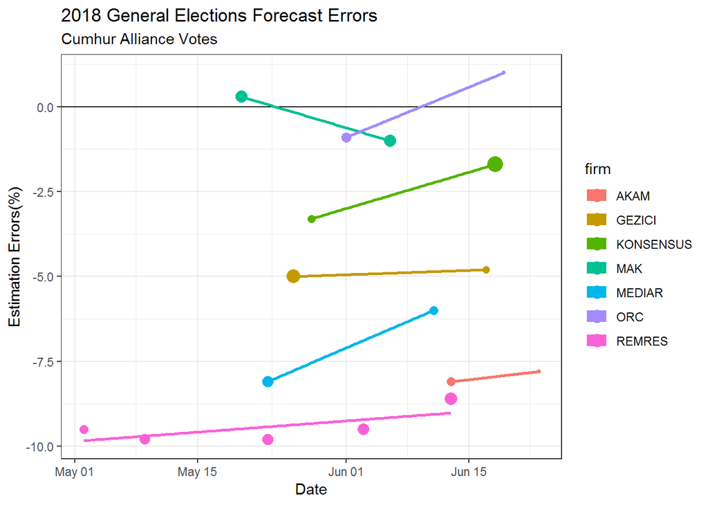

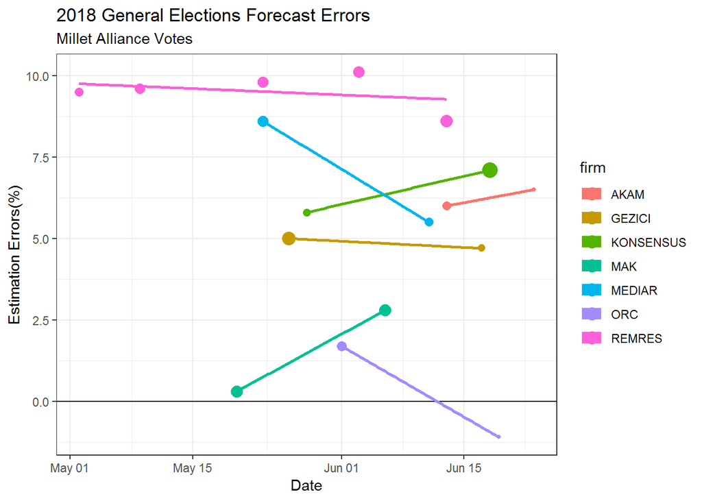

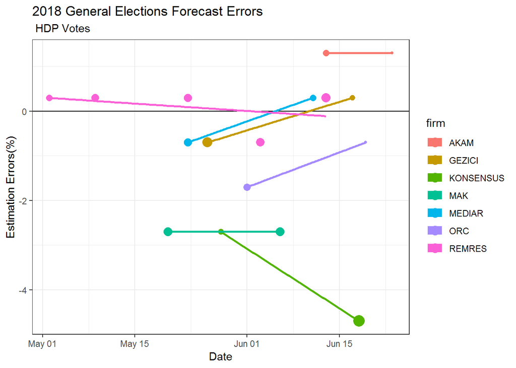

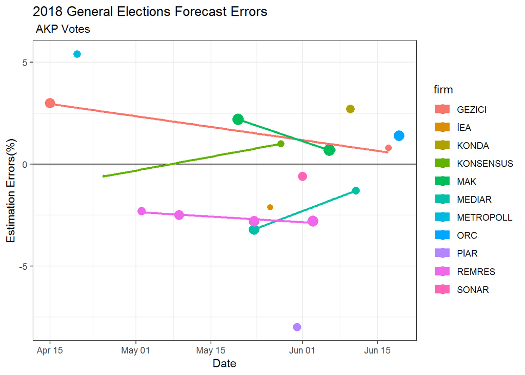

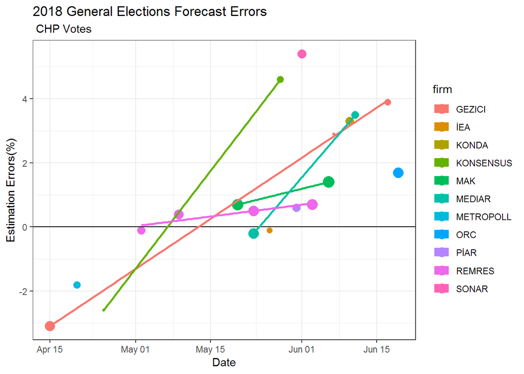

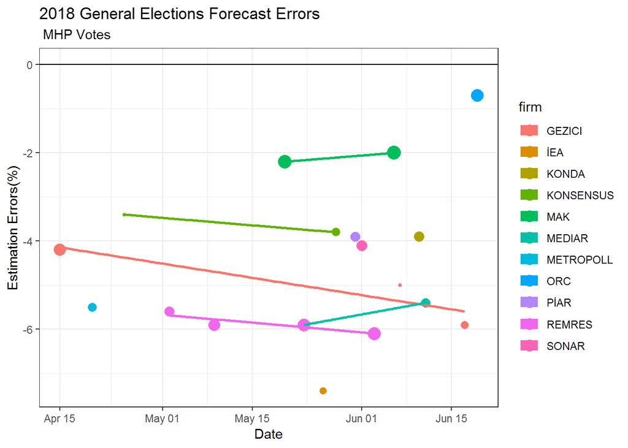

[figure not shown]

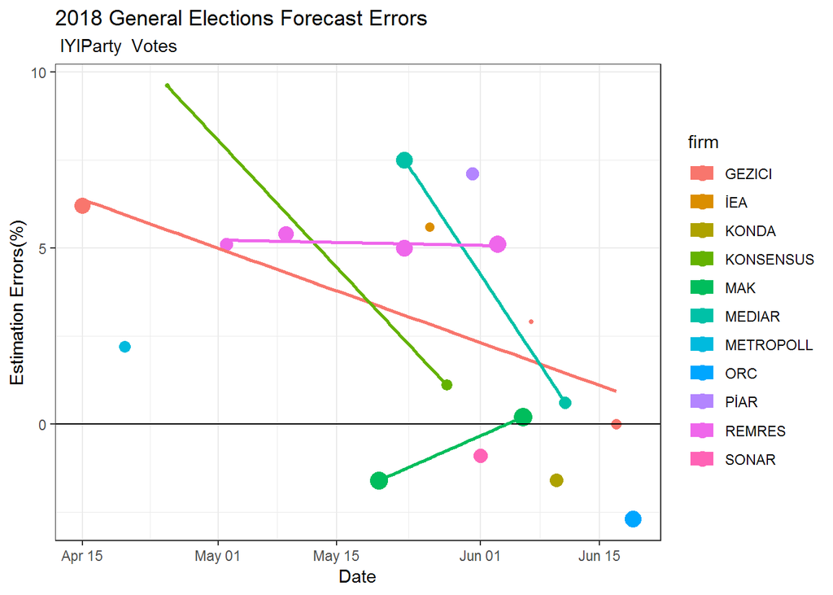

### 2019

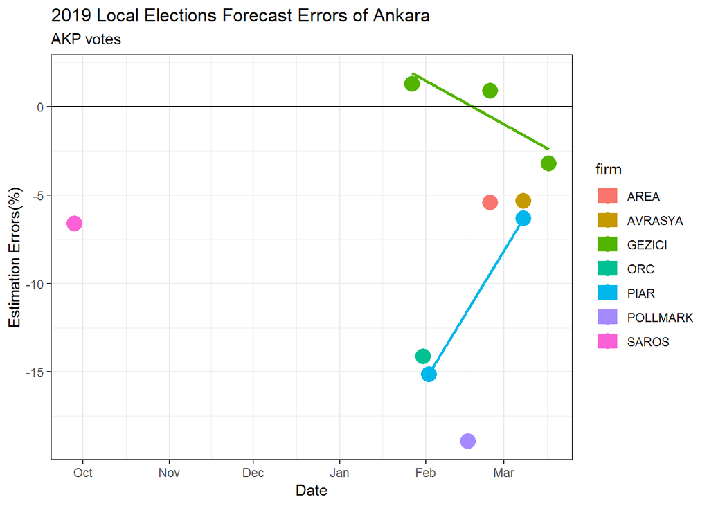

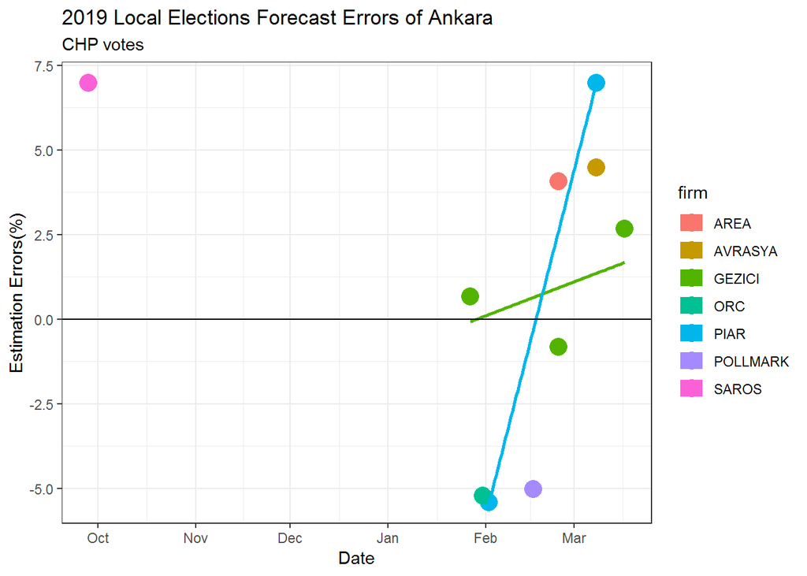

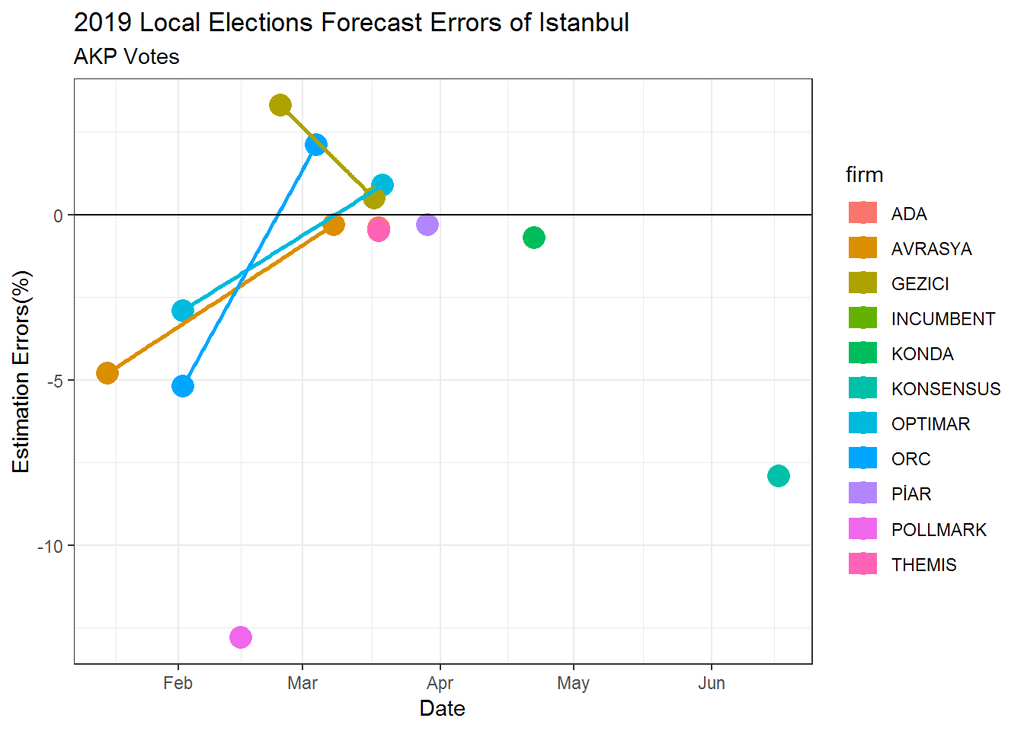

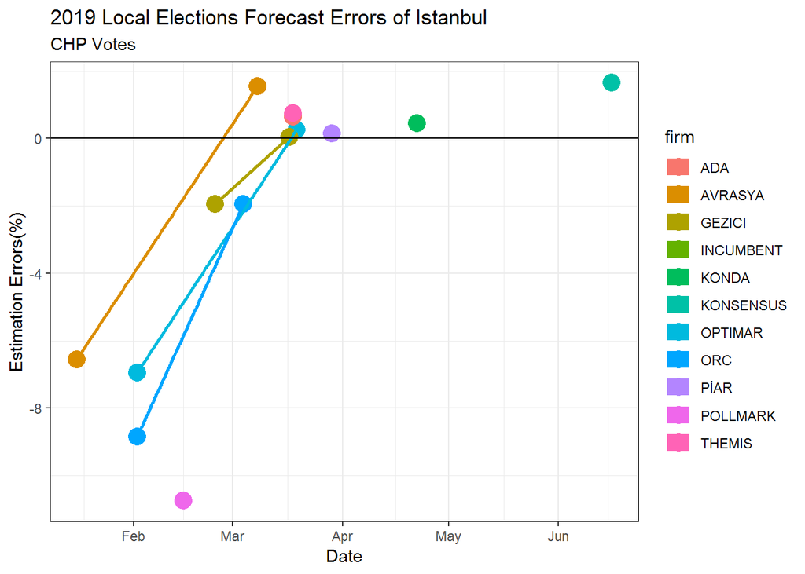